# PLS

G7

2024-05-05

# VARIABLE SELECTION

```r
df <- read_excel("df_definitivo-2.xlsx", sheet = "Copia de datos")
rownames(df) = df$id
df$Afectacion_ganglionar = as.numeric(df$Afectacion_ganglionar)
df$Afectacion_metastasica = as.numeric(df$Afectacion_metastasica)
df$Tamaño_tumor = as.numeric(df$Tamaño_tumor)
df$Grado_tox = as.numeric(df$Grado_tox)
df$SII_pre = log(df$SII_pre)
df$SII_1C = log(df$SII_1C)
df$SII_2C = log(df$SII_2C)
df$SII_1eval = log(df$SII_1eval)

variables_inutiles = c("Anciano", "Peso", "Talla", "SG", "SG_cens", "SLP", "SLP_cens", "Tipo_tox", "NLR2C_corte4o5")
df2 = select(df, -all_of(variables_inutiles))
```

# SPECIFIC VARIABLES FIRST EVAL

```r
#colnames(df2)
X1.1 = df2[,2:49]
X1.2 = df2[,61:67]
X = bind_cols(X1.1, X1.2)
Y = as.matrix(df2['pri_eval_num_ok'])
```

# SPECIFIC VARIABLES BEST RESPONSE

```r
#colnames(df2)
X2 = df2[,2:67]
Y2 = as.matrix(df2["mejor_resp_num_ok"])
```

# SCALING

```r
mypls = opls(x = X, y = Y, predI = NA, crossvalI = nrow(X), scaleC = "standard", fig.pdfC = "none")
```

```
## PLS
## 34 samples x 55 variables and 1 response
## standard scaling of predictors and response(s)
##       R2X(cum) R2Y(cum) Q2(cum) RMSEE pre ort pR2Y  pQ2
## Total    0.147    0.526   0.295 0.489   1   0 0.05 0.05
```

# NUMBER OF COMPONENTS SELECTION

```r
mypls_2 = opls(x = X, y = Y, predI = 33, crossvalI = nrow(X), scaleC = "standard", fig.pdfC = "none")
```

```
## PLS
## 34 samples x 55 variables and 1 response
## standard scaling of predictors and response(s)
##       R2X(cum) R2Y(cum) Q2(cum) RMSEE pre ort pR2Y  pQ2
## Total        1        1       1   Inf  33   0 1.05 1.05
```

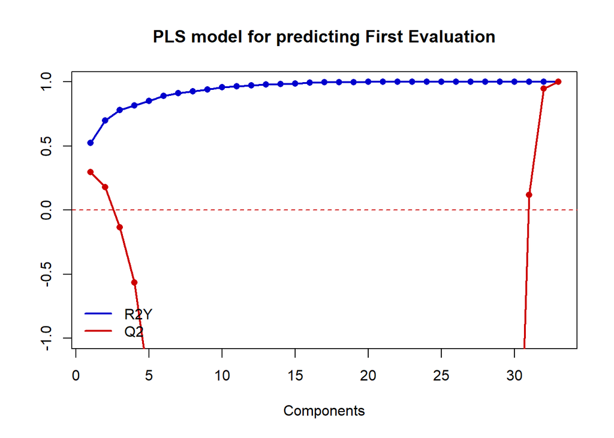

```r
plot(1:33, mypls_2@modelDF$`R2Y(cum)`, type = "o", pch = 16, col = "blue3",
     lwd = 2, xlab = "Components", ylab = "",
     main = "PLS model for predicting First Evaluation", ylim = c(-1,1))
lines(1:33, mypls_2@modelDF$`Q2(cum)`, type = "o", pch = 16, col = "red3",
      lwd = 2)
abline(h = 0, col = "red3", lty = 2)
legend("bottomleft", c("R2Y", "Q2"), lwd = 2,
       col = c("blue3", "red3"), bty = "n")
```

```r
mypls = opls(x = X, y = Y, predI = 2, crossvalI = nrow(X), scaleC = "standard", fig.pdfC = "none")
```

```
## PLS
## 34 samples x 55 variables and 1 response
## standard scaling of predictors and response(s)
##       R2X(cum) R2Y(cum) Q2(cum) RMSEE pre ort pR2Y  pQ2
## Total    0.242      0.7   0.178 0.395   2   0 0.15 0.05
```

# EXTREME INDIVIDUALS STUDY

To study the anomalous data we will use Hotelling’s T2 and the Residual Sum of Squares.

In the PCA we observed that individual 11 is an extreme outlier. But we will still represent it in the Hotelling T2 plot.

```r
misScores = mypls@scoreMN
varT = apply(misScores, 2, var)
miT2 = colSums(t(misScores**2) / varT)
N = nrow(X)
A = 2
F95 = A*(N**2 - 1)/(N*(N - A)) * qf(0.95, A, N-A); F95
```

```
## [1] 6.994835
```

```r
F99 = A*(N**2 - 1)/(N*(N - A)) * qf(0.99, A, N-A); F99
```

```
## [1] 11.32992
```

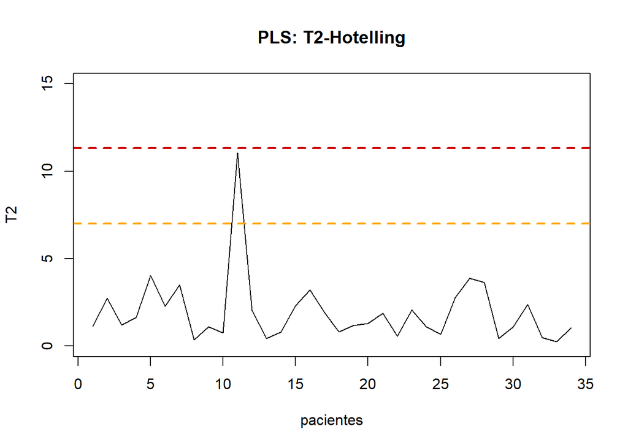

```r
plot(1:length(miT2), miT2, type = "l", xlab = "pacientes", ylab = "T2",
     main = "PLS: T2-Hotelling", ylim = c(0,15))
abline(h = F95, col = "orange", lty = 2, lwd = 2)
abline(h = F99, col = "red3", lty = 2, lwd = 2)
```

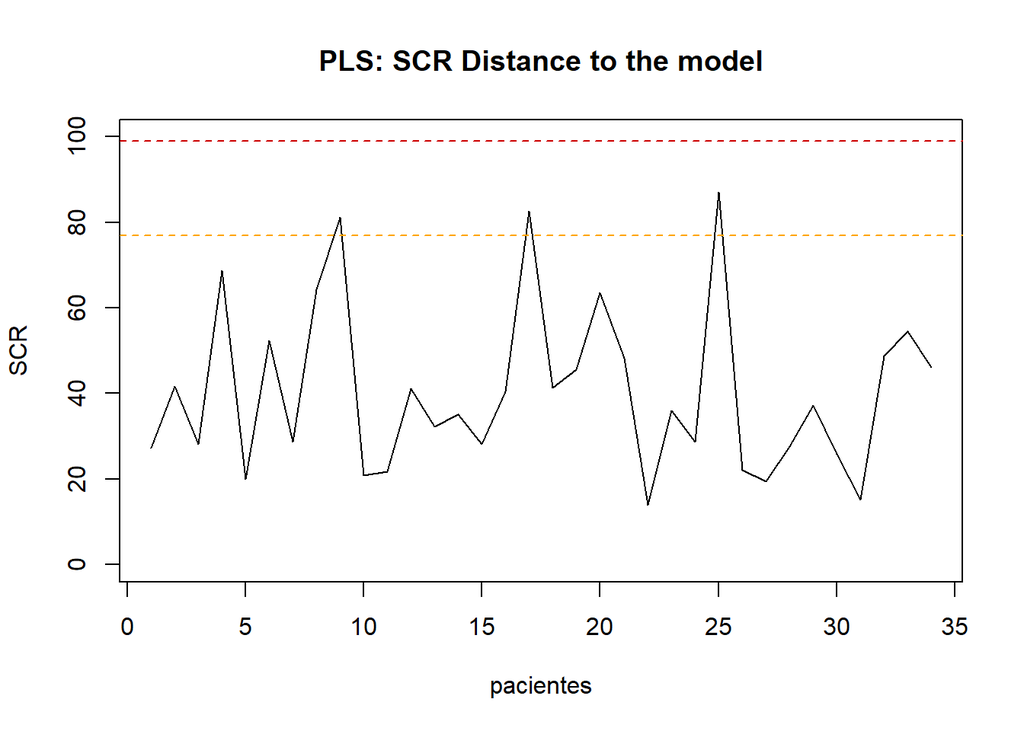

```r
myT = mypls@scoreMN
myP = mypls@loadingMN
myE = scale(X) - myT%*%t(myP)
mySCR = rowSums(myE^2)   # SPE
plot(1:length(mySCR), mySCR, type = "l", main = "PLS: SCR Distance to the model",
     ylab = "SCR", xlab = "pacientes", ylim = c(0,100))
g = var(mySCR)/(2*mean(mySCR))
h = (2*mean(mySCR)^2)/var(mySCR)
chi2lim = g*qchisq(0.95, df = h)
abline(h = chi2lim, col = "orange", lty = 2)
chi2lim99 = g*qchisq(0.99, df = h)
abline(h = chi2lim99, col = "red3", lty = 2)
```

# GRPAHICS

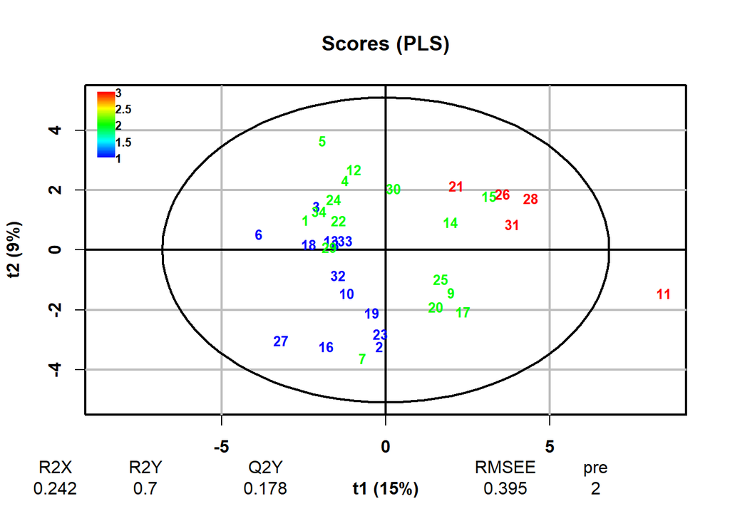

```r
plot(x = mypls, typeVc = "x-score", parCompVi = c(1, 2), parLabVc = rownames(X), parPaletteVc = NA, parTitleL = TRUE, parCexMetricN = NA)
```

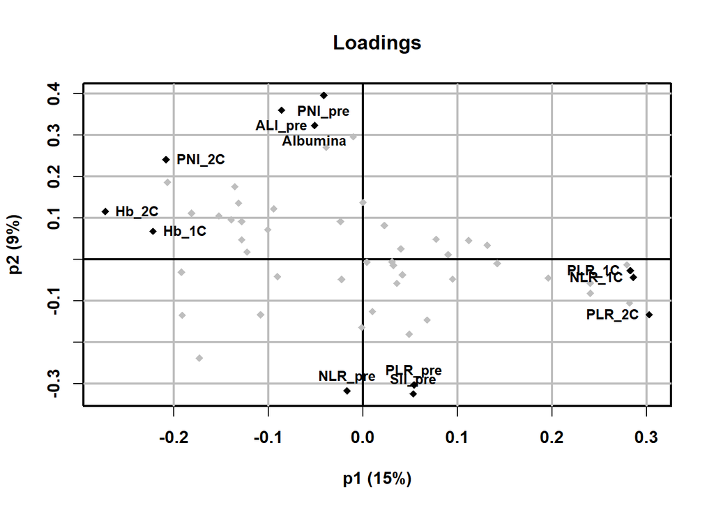

```r
plot(x = mypls, typeVc = "x-loading",
     parCexN = 0.8, parCompVi = c(1, 2), parPaletteVc = NA,
     parTitleL = TRUE, parCexMetricN = NA)
```

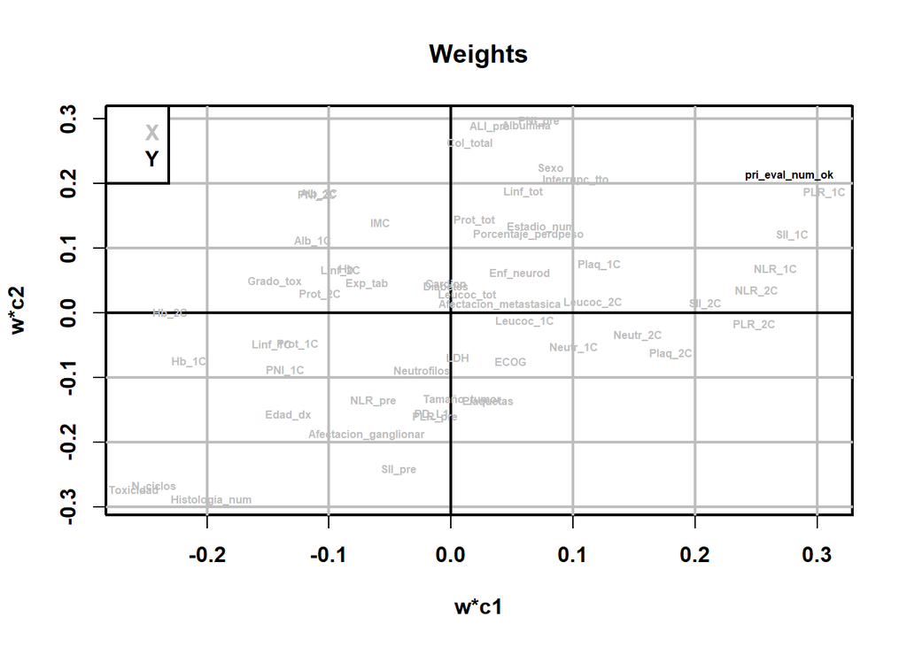

```r
plot(x = mypls, typeVc = "xy-weight",
     parCexN = 0.5, parCompVi = c(1, 2), parPaletteVc = NA,
     parTitleL = TRUE, parCexMetricN = NA)
```

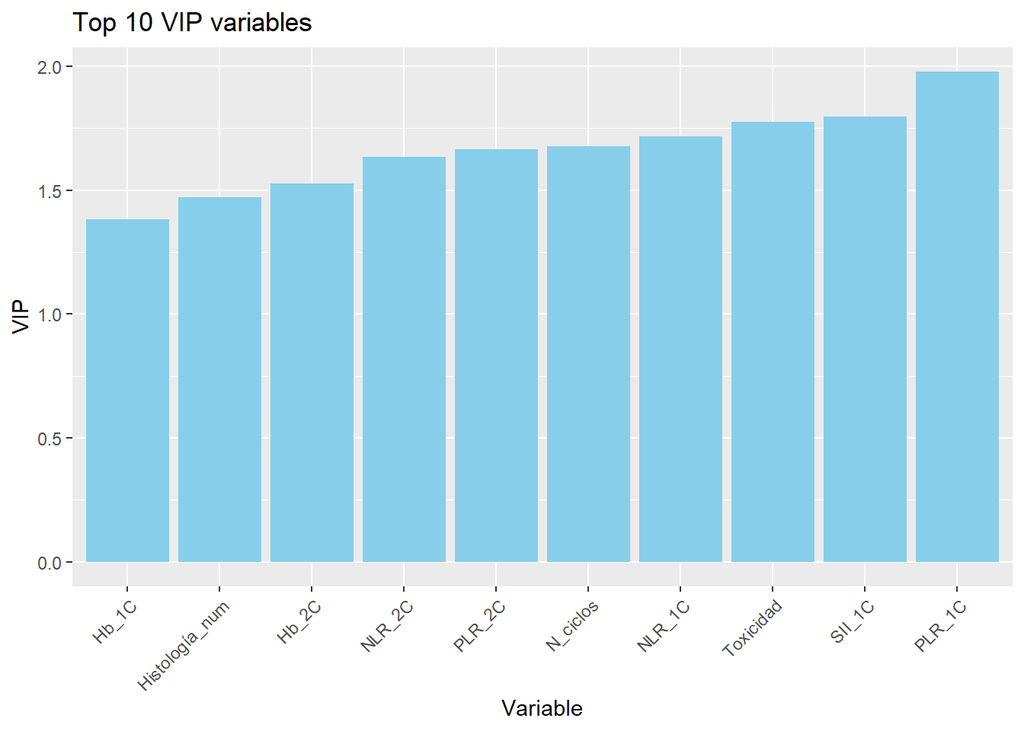

```r
VIP = data.frame(sort(mypls@vipVn))
bottom_10 <- data.frame(variables = rownames(VIP)[1:10], vip = VIP[1:10, ])
top_10 <- data.frame(variables = rownames(VIP)[46:55], vip = VIP[46:55, ])

grafico_barras <- ggplot(top_10, aes(x = reorder(variables, vip), y = vip)) + geom_bar(stat = "identity", fill = "skyblue") + theme(axis.text.x = element_text(angle = 45, hjust = 1)) +  labs(x = "Variable", y = "VIP", title = "Top 10 VIP variables")

grafico_barras2 <- ggplot(bottom_10, aes(x = reorder(variables, vip), y = vip)) + geom_bar(stat = "identity", fill = "skyblue") + theme(axis.text.x = element_text(angle = 45, hjust = 1)) +  labs(x = "Variable", y = "VIP", title = "Bottom 10 VIP variables")

print(grafico_barras)
```

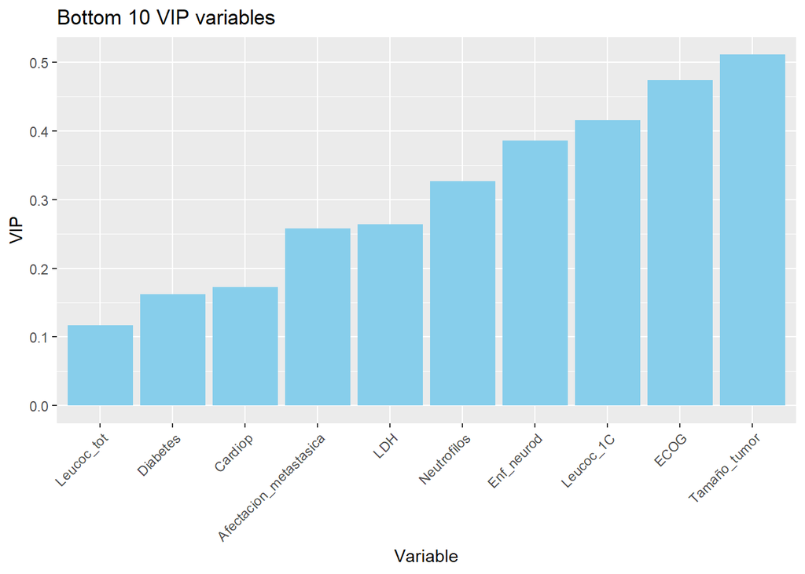

```r
print(grafico_barras2)
```

# EVALUATION METRICS FOR REGRESSION

```r
Ypred = predict(mypls)
residuos = Y-Ypred
myRMSE = sqrt(colMeans(residuos^2))
CVrmse = myRMSE/colMeans(Y)
myRMSE
```

```
## pri_eval_num_ok
##       0.3771181
```

```r
CVrmse
```

```
## pri_eval_num_ok
##       0.2137002
```

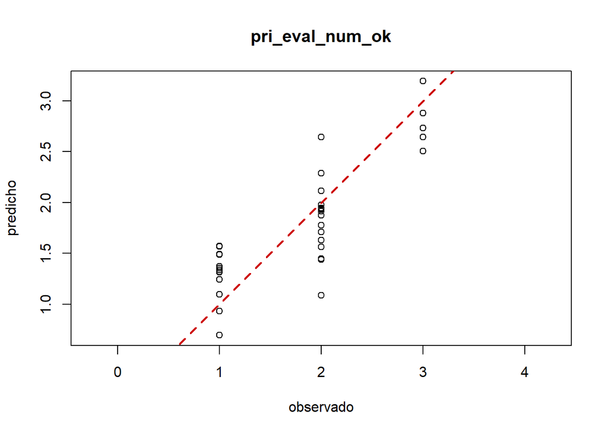

```r
for (i in 1:ncol(Y)) {
  plot(Y[,i], Ypred[,i], asp = 1, main = colnames(Y)[i],
     xlab = "observado", ylab = "predicho")
abline(a=0, b=1, col = "red3", lwd = 2, lty = 2)
}
```

# SCALING

```r
mypls2 = opls(x = X2, y = Y2, predI = NA, crossvalI = nrow(X), scaleC = "standard", fig.pdfC = "none")
```

```
## PLS
## 34 samples x 66 variables and 1 response
## standard scaling of predictors and response(s)
##       R2X(cum) R2Y(cum) Q2(cum) RMSEE pre ort pR2Y  pQ2
## Total    0.172    0.595   0.416 0.593   1   0 0.05 0.05
```

```r
mypls_2.2 = opls(x = X2, y = Y2, predI = 33, crossvalI = nrow(X), scaleC = "standard", fig.pdfC = "none")
```

```
## PLS
## 34 samples x 66 variables and 1 response
## standard scaling of predictors and response(s)
##       R2X(cum) R2Y(cum) Q2(cum) RMSEE pre ort pR2Y  pQ2
## Total        1        1       1   Inf  33   0 1.05 1.05
```

# NUMBER OF COMPONENTS SELECTION

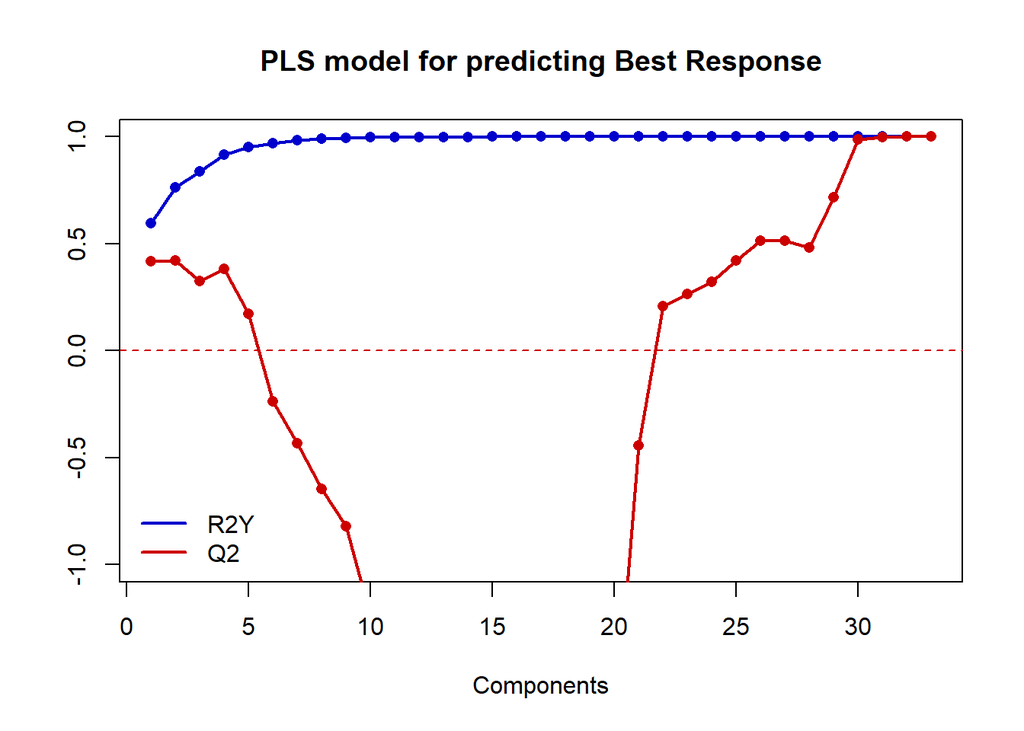

```r
plot(1:33, mypls_2.2@modelDF$`R2Y(cum)`, type = "o", pch = 16, col = "blue3",
     lwd = 2, xlab = "Components", ylab = "",
     main = "PLS model for predicting Best Response", ylim = c(-1,1))
lines(1:33, mypls_2.2@modelDF$`Q2(cum)`, type = "o", pch = 16, col = "red3",
      lwd = 2)
abline(h = 0, col = "red3", lty = 2)
legend("bottomleft", c("R2Y", "Q2"), lwd = 2,
       col = c("blue3", "red3"), bty = "n")
```

```r
mypls_2 = opls(x = X2, y = Y2, predI = 4, crossvalI = nrow(X), scaleC = "standard", fig.pdfC = "none")
```

```
## PLS
## 34 samples x 66 variables and 1 response
## standard scaling of predictors and response(s)
##       R2X(cum) R2Y(cum) Q2(cum) RMSEE pre ort pR2Y  pQ2
## Total    0.475    0.915   0.381 0.286   4   0 0.05 0.05
```

# EXTREME INDIVIDUALS STUDY

To study the anomalous data we will use Hotelling’s T2 and the Residual Sum of Squares.

In the PCA we observed that individual 11 is an extreme outlier. But we will still represent it in the Hotelling T2 plot.

```r
misScores = mypls_2@scoreMN
varT = apply(misScores, 2, var)
miT2 = colSums(t(misScores**2) / varT)
N = nrow(X2)
A = 2
F95 = A*(N**2 - 1)/(N*(N - A)) * qf(0.95, A, N-A); F95
```

```
## [1] 6.994835
```

```r
F99 = A*(N**2 - 1)/(N*(N - A)) * qf(0.99, A, N-A); F99
```

```
## [1] 11.32992
```

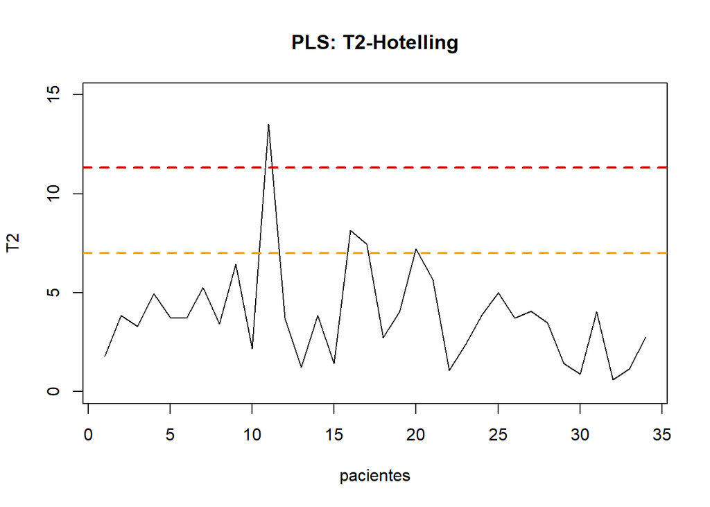

```r
plot(1:length(miT2), miT2, type = "l", xlab = "pacientes", ylab = "T2",
     main = "PLS: T2-Hotelling", ylim = c(0,15))
abline(h = F95, col = "orange", lty = 2, lwd = 2)
abline(h = F99, col = "red3", lty = 2, lwd = 2)
```

Individual 11 continues to come out as extreme data, even when performing logarithmic transformations.

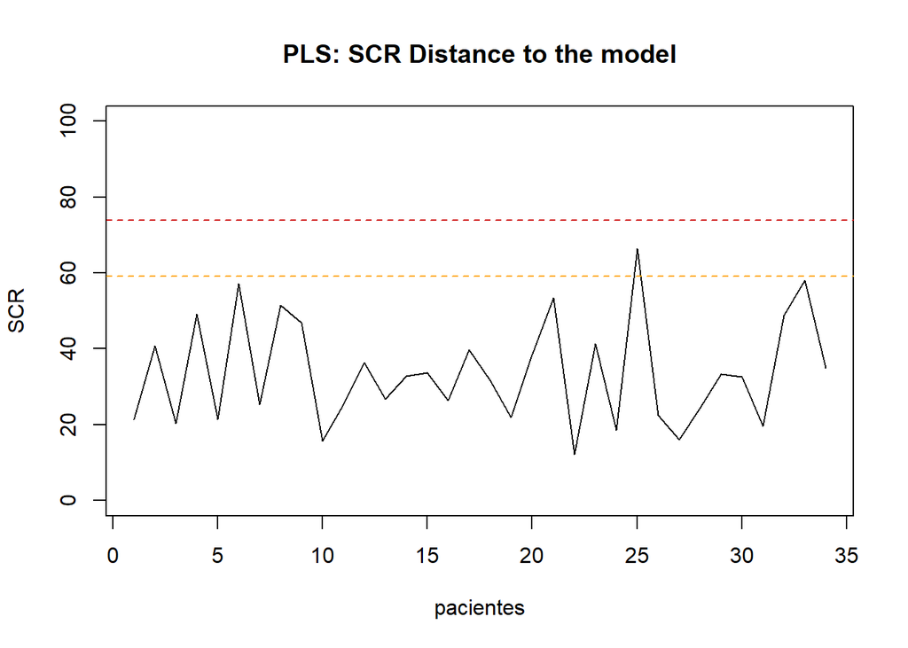

```r
myT = mypls_2@scoreMN
myP = mypls_2@loadingMN
myE = scale(X2) - myT%*%t(myP)
mySCR = rowSums(myE^2)   # SPE
plot(1:length(mySCR), mySCR, type = "l", main = "PLS: SCR Distance to the model",
     ylab = "SCR", xlab = "pacientes", ylim = c(0,100))
g = var(mySCR)/(2*mean(mySCR))
h = (2*mean(mySCR)^2)/var(mySCR)
chi2lim = g*qchisq(0.95, df = h)
abline(h = chi2lim, col = "orange", lty = 2)
chi2lim99 = g*qchisq(0.99, df = h)
abline(h = chi2lim99, col = "red3", lty = 2)
```

# GRAPHICS

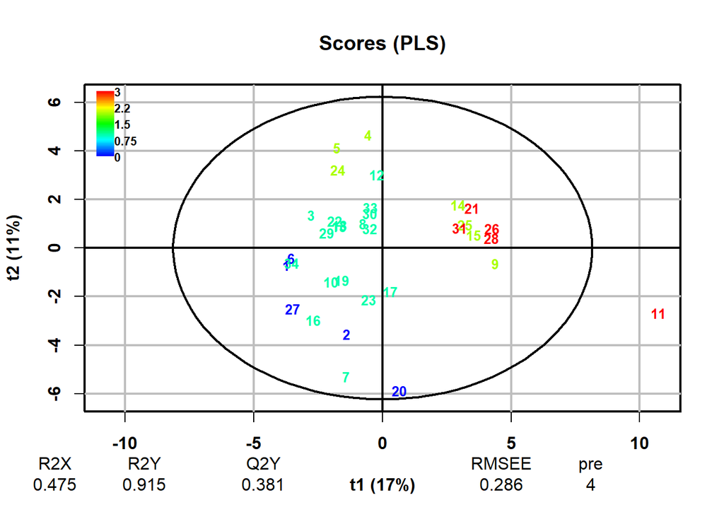

```r
plot(x = mypls_2, typeVc = "x-score", parCompVi = c(1, 2), parLabVc = rownames(X), parPaletteVc = NA, parTitleL = TRUE, parCexMetricN = NA)
```

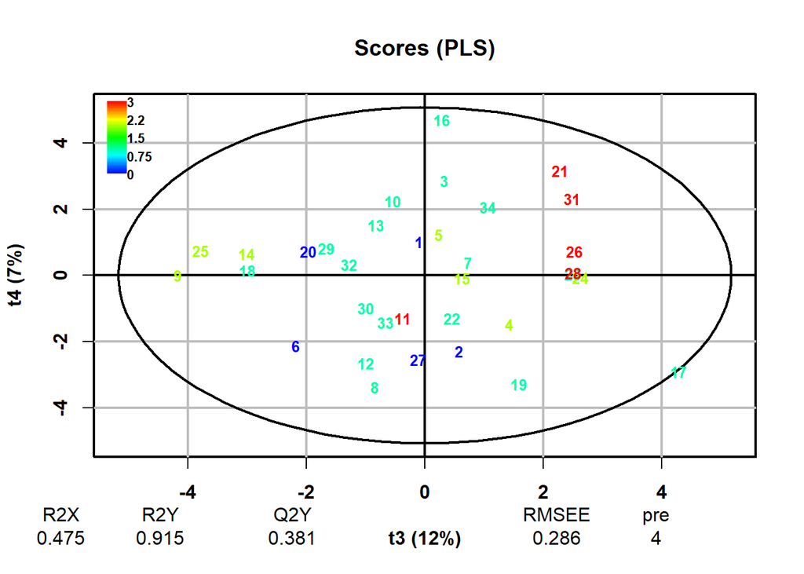

```r
plot(x = mypls_2, typeVc = "x-score", parCompVi = c(3, 4), parLabVc = rownames(X), parPaletteVc = NA, parTitleL = TRUE, parCexMetricN = NA)
```

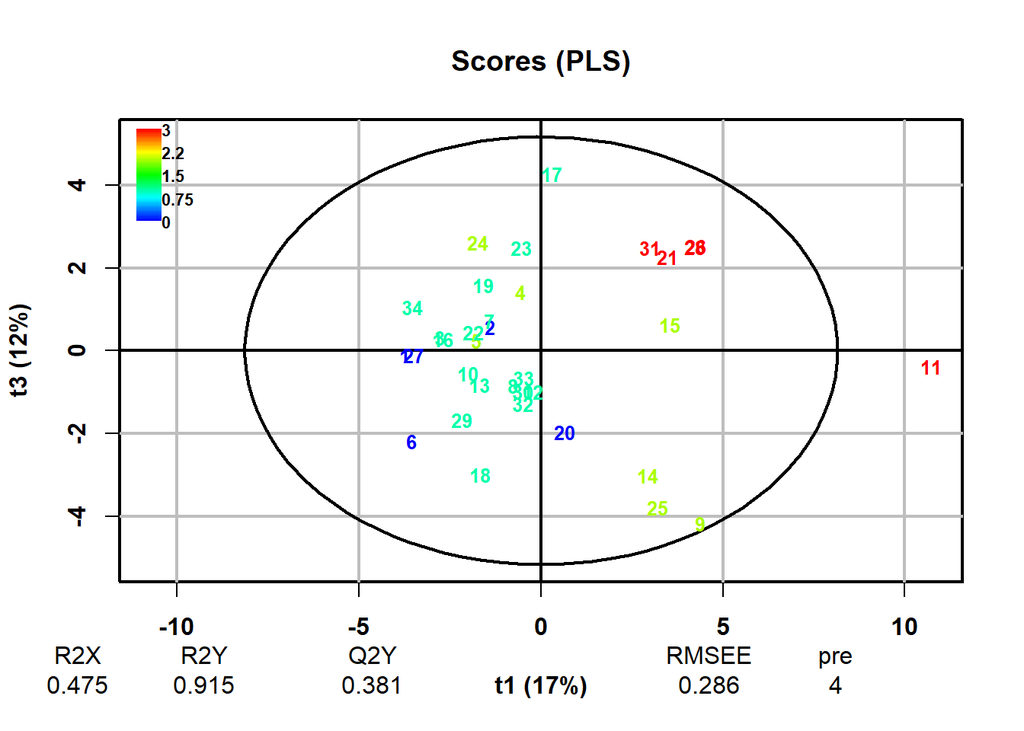

```r
plot(x = mypls_2, typeVc = "x-score", parCompVi = c(1,3), parLabVc = rownames(X), parPaletteVc = NA, parTitleL = TRUE, parCexMetricN = NA)
```

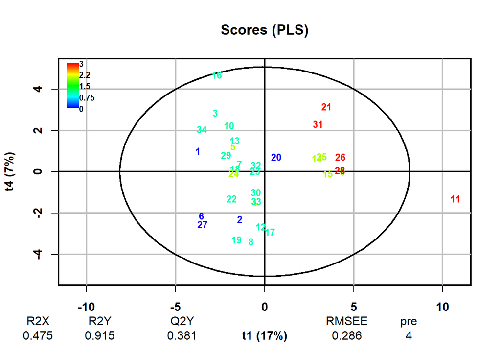

```r
plot(x = mypls_2, typeVc = "x-score", parCompVi = c(1, 4), parLabVc = rownames(X), parPaletteVc = NA, parTitleL = TRUE, parCexMetricN = NA)
```

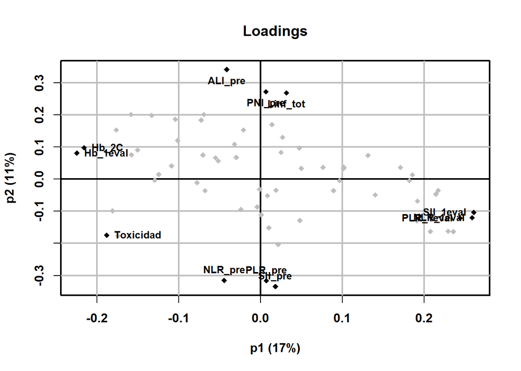

```r
plot(x = mypls_2, typeVc = "x-loading",
     parCexN = 0.8, parCompVi = c(1, 2), parPaletteVc = NA,
     parTitleL = TRUE, parCexMetricN = NA)
```

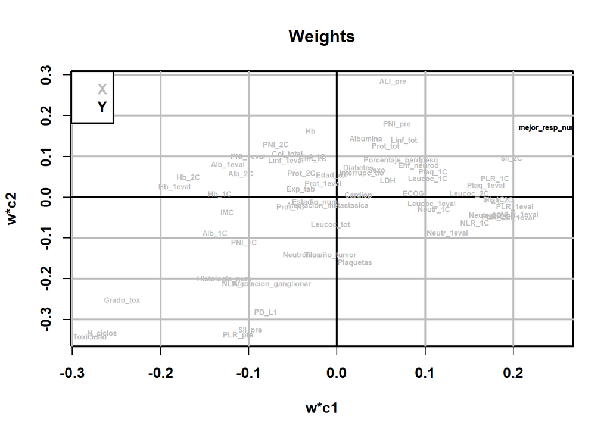

```r
plot(x = mypls_2, typeVc = "xy-weight",
     parCexN = 0.5, parCompVi = c(1, 2), parPaletteVc = NA,
     parTitleL = TRUE, parCexMetricN = NA)
```

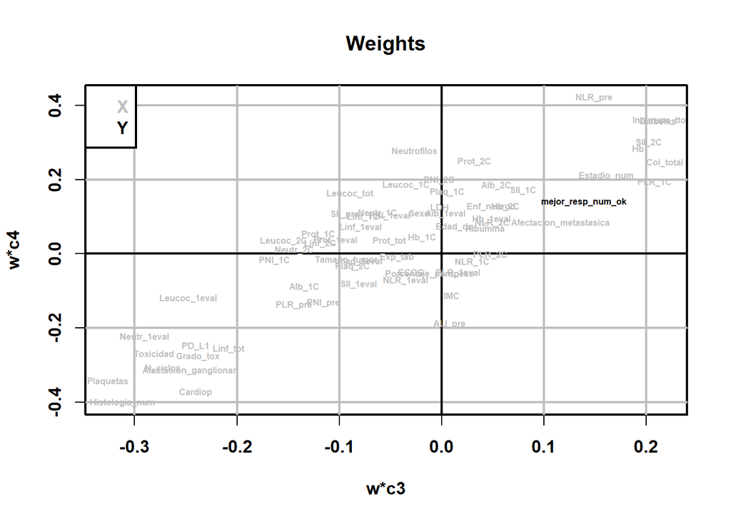

```r
plot(x = mypls_2, typeVc = "xy-weight",
     parCexN = 0.5, parCompVi = c(3, 4), parPaletteVc = NA,
     parTitleL = TRUE, parCexMetricN = NA)
```

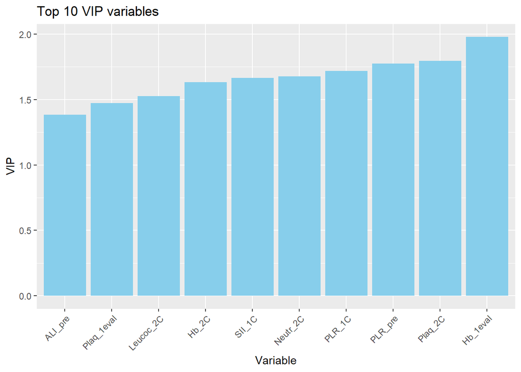

```r
VIP2 = data.frame(sort(mypls_2@vipVn))
bottom_10 <- data.frame(variables = rownames(VIP2)[1:10], vip = VIP[1:10, ])
top_10 <- data.frame(variables = rownames(VIP2)[46:55], vip = VIP[46:55, ])

grafico_barras <- ggplot(top_10, aes(x = reorder(variables, vip), y = vip)) + geom_bar(stat = "identity", fill = "skyblue") + theme(axis.text.x = element_text(angle = 45, hjust = 1)) +  labs(x = "Variable", y = "VIP", title = "Top 10 VIP variables")

grafico_barras2 <- ggplot(bottom_10, aes(x = reorder(variables, vip), y = vip)) + geom_bar(stat = "identity", fill = "skyblue") + theme(axis.text.x = element_text(angle = 45, hjust = 1)) +  labs(x = "Variable", y = "VIP", title = "Bottom 10 VIP variables")

print(grafico_barras)
```

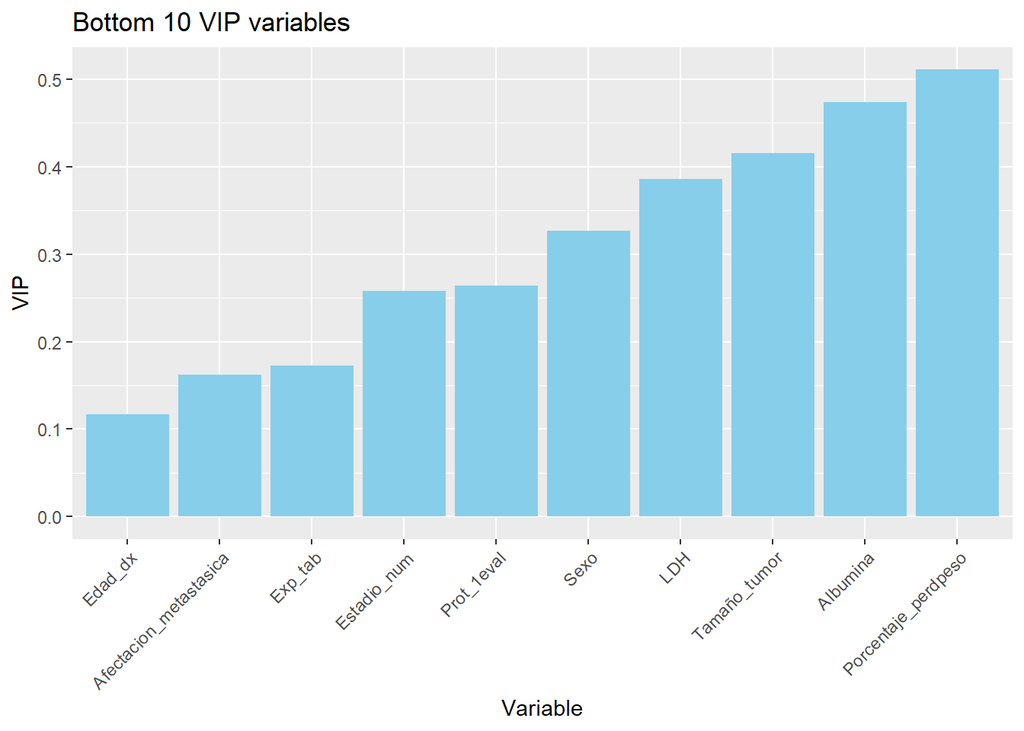

```r
print(grafico_barras2)
```

# EVALUATION METRICS FOR REGRESSION

```r
Ypred2 = predict(mypls_2)
residuos2 = Y2-Ypred2
myRMSE2 = sqrt(colMeans(residuos2^2))
CVrmse2 = myRMSE2/colMeans(Y2)
myRMSE2
```

```
## mejor_resp_num_ok
##         0.2638897
```

```r
CVrmse2
```

```
## mejor_resp_num_ok
##         0.1950489
```

The CVrmse we obtain is 0.195 which means that the model predictions have an error of 19.5% in relation to the scale of the original data. With this value we could say that the model has a moderate-acceptable performance.

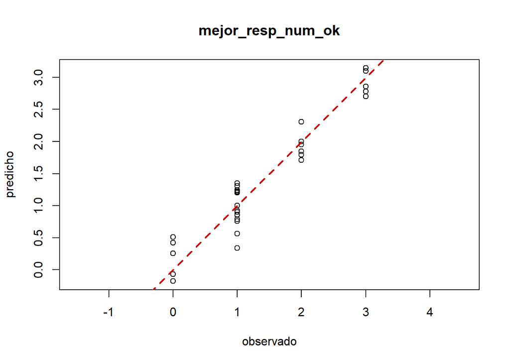

```r
for (i in 1:ncol(Y)) {
  plot(Y2[,i], Ypred2[,i], asp = 1, main = colnames(Y2)[i],
     xlab = "observado", ylab = "predicho")
abline(a=0, b=1, col = "red3", lwd = 2, lty = 2)
}
```

# SPECIFIC VARIABLES FIRST EVAL

```r
X1.1 = df2[,2:49]
X1.2 = df2[,61:67]
X = bind_cols(X1.1, X1.2)
Y = df2$pri_eval_num_ok
Y = as.matrix(as.factor(Y))
```

# SPECIFIC VARIABLES BEST RESPONSE

```r
X2 = df2[,2:67]
Y2 = df2$mejor_resp_num_ok
Y2 = as.matrix(as.factor(Y2))
```

# SCALING

```r
myplsda = opls(x = X, y = Y, predI = 33, crossvalI = nrow(X), scaleC = "standard", fig.pdfC = "none")
```

```
## PLS-DA
## 34 samples x 55 variables and 1 response
## standard scaling of predictors and response(s)
##       R2X(cum) R2Y(cum) Q2(cum) RMSEE pre ort pR2Y  pQ2
## Total        1        1       1   Inf  33   0 1.05 1.05
```

# NUMBER OF COMPONENTS SELECTION

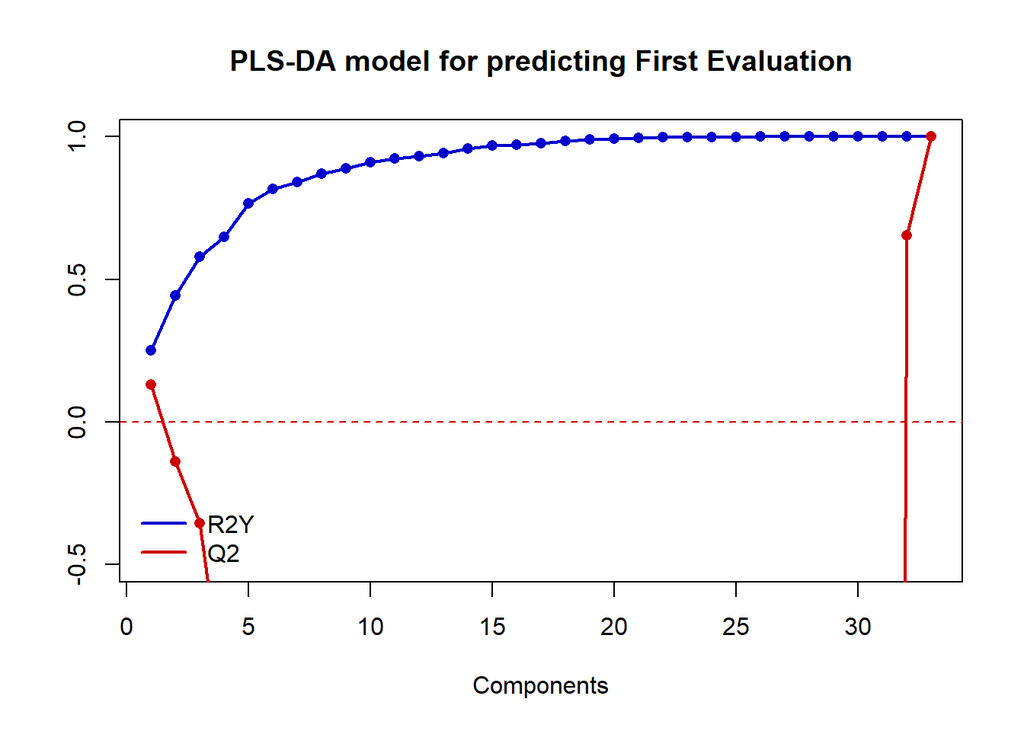

```r
plot(1:33, myplsda@modelDF$`R2Y(cum)`, type = "o", pch = 16, col = "blue3",
     lwd = 2, xlab = "Components", ylab = "", ylim = c(-0.5, 1),
     main = "PLS-DA model for predicting First Evaluation")
lines(1:33, myplsda@modelDF$`Q2(cum)`, type = "o", pch = 16, col = "red3",
      lwd = 2)
abline(h = 0, col = "red3", lty = 2)
legend("bottomleft", c("R2Y", "Q2"), lwd = 2,
       col = c("blue3", "red3"), bty = "n")
```

```r
myplsda = opls(x = X, y = Y, predI = 2, crossvalI = nrow(X), scaleC = "standard", fig.pdfC = "none")
```

```
## PLS-DA
## 34 samples x 55 variables and 1 response
## standard scaling of predictors and response(s)
##       R2X(cum) R2Y(cum) Q2(cum) RMSEE pre ort pR2Y pQ2
## Total     0.25    0.442   -0.14 0.361   2   0  0.2 0.2
```

# EXTREME INDIVIDUALS STUDY

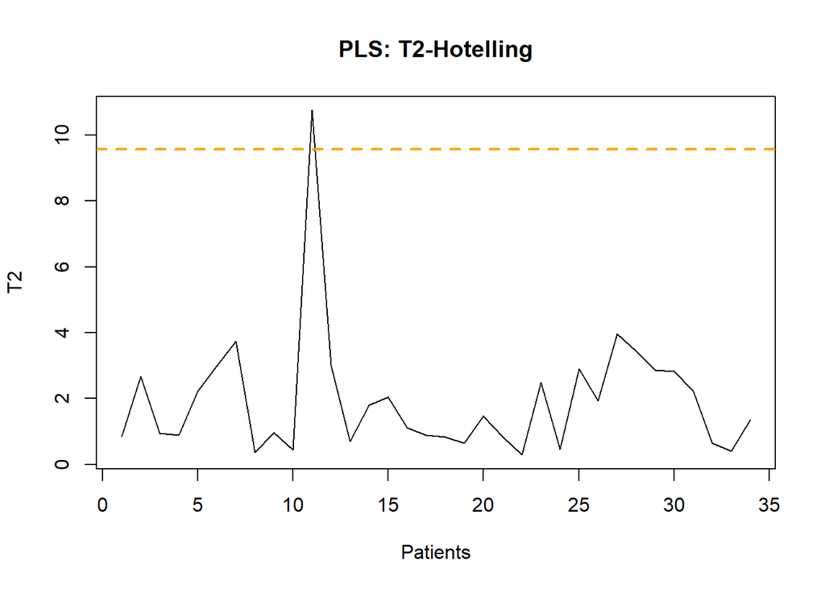

```r
misScores = myplsda@scoreMN
varT = apply(misScores, 2, var)
miT2 = colSums(t(misScores**2) / varT)
N = nrow(X)
A = 3
F95 = A*(N**2 - 1)/(N*(N - A)) * qf(0.95, A, N-A);
F99 = A*(N**2 - 1)/(N*(N - A)) * qf(0.99, A, N-A);

plot(1:length(miT2), miT2, type = "l", xlab = "Patients", ylab = "T2",
     main = "PLS: T2-Hotelling")
abline(h = F95, col = "orange", lty = 2, lwd = 2)
abline(h = F99, col = "red3", lty = 2, lwd = 2)
```

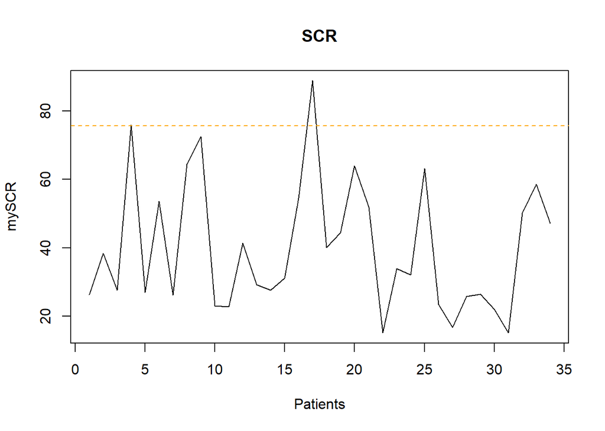

```r
myT = myplsda@scoreMN
myP = myplsda@loadingMN
myE = scale(X) - myT%*%t(myP)
mySCR = rowSums(myE^2)   # SPE
plot(1:length(mySCR), mySCR, type = "l", main = "SCR",
     xlab = "Patients")

g = var(mySCR)/(2*mean(mySCR))
h = (2*mean(mySCR)^2)/var(mySCR)
chi2lim = g*qchisq(0.95, df = h)
abline(h = chi2lim, col = "orange", lty = 2)
chi2lim99 = g*qchisq(0.99, df = h)
abline(h = chi2lim99, col = "red3", lty = 2)
```

# GRAPHICS

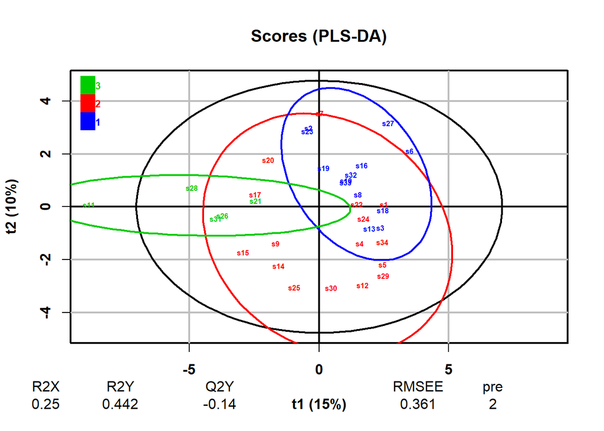

```r
plot(x = myplsda, typeVc = "x-score",
     parCexN = 0.5, parCompVi = c(1, 2), parPaletteVc = NA,
     parTitleL = TRUE, parCexMetricN = NA)
```

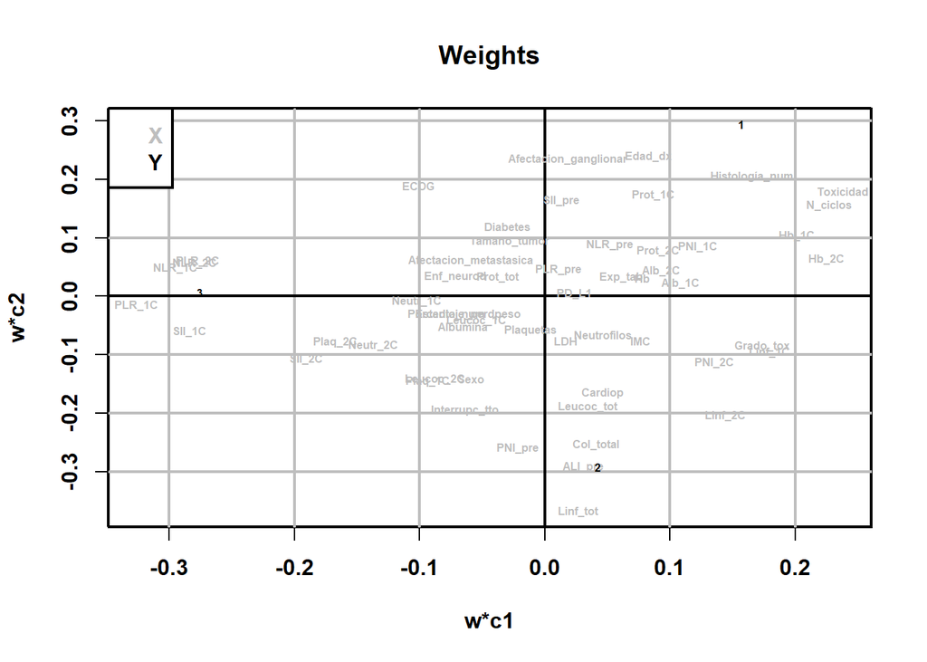

```r
plot(x = myplsda, typeVc = "xy-weight",
     parCexN = 0.5, parCompVi = c(1, 2), parPaletteVc = NA,
     parTitleL = TRUE, parCexMetricN = NA)
```

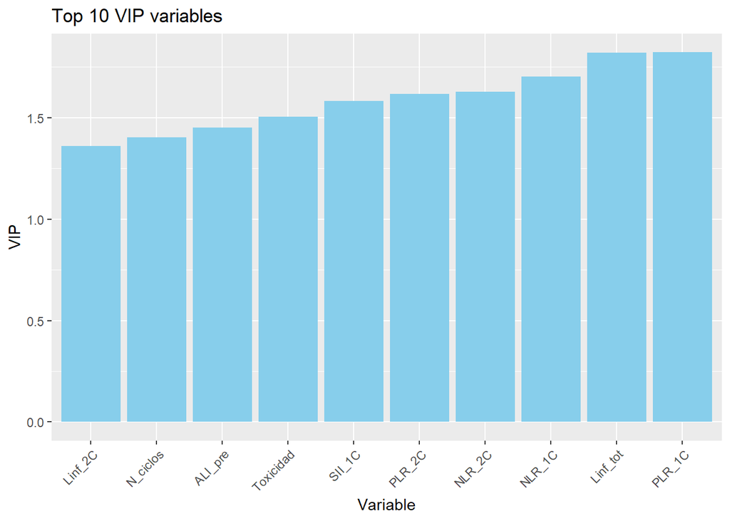

```r
VIP = data.frame(sort(myplsda@vipVn))
bottom_10 <- data.frame(variables = rownames(VIP)[1:10], vip = VIP[1:10, ])
top_10 <- data.frame(variables = rownames(VIP)[46:55], vip = VIP[46:55, ])

grafico_barras <- ggplot(top_10, aes(x = reorder(variables, vip), y = vip)) + geom_bar(stat = "identity", fill = "skyblue") + theme(axis.text.x = element_text(angle = 45, hjust = 1)) +  labs(x = "Variable", y = "VIP", title = "Top 10 VIP variables")

grafico_barras2 <- ggplot(bottom_10, aes(x = reorder(variables, vip), y = vip)) + geom_bar(stat = "identity", fill = "skyblue") + theme(axis.text.x = element_text(angle = 45, hjust = 1)) +  labs(x = "Variable", y = "VIP", title = "Bottom 10 VIP variables")

print(grafico_barras)
```

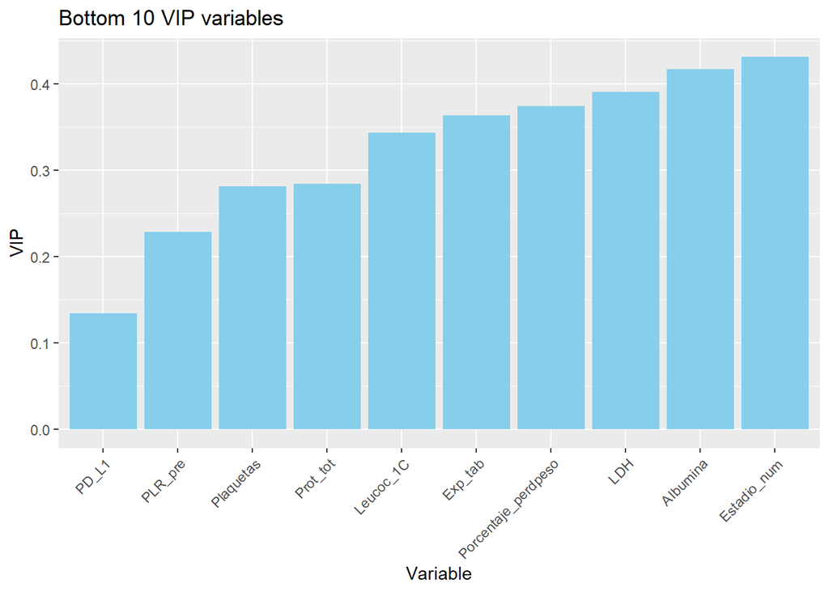

```r
print(grafico_barras2)
```

# EVALUATION METRICS FOR CLASSIFICATION

```r
myplsda_pred = predict(myplsda)
actual = factor(df2$pri_eval_num_ok)
myplsda_pred <- factor(myplsda_pred, levels = levels(actual))
confusionMatrix(myplsda_pred, actual, positive = "3")
```

```
## Confusion Matrix and Statistics
##
##           Reference
## Prediction  1  2  3
##          1 11  4  0
##          2  2 11  0
##          3  0  1  5
##
## Overall Statistics
##
##                Accuracy : 0.7941
##                  95% CI : (0.621, 0.913)
##     No Information Rate : 0.4706
##     P-Value [Acc > NIR] : 0.0001154
##
##                   Kappa : 0.6708
##
##  Mcnemar's Test P-Value : NA
##
## Statistics by Class:
##
##                      Class: 1 Class: 2 Class: 3
## Sensitivity            0.8462   0.6875   1.0000
## Specificity            0.8095   0.8889   0.9655
## Pos Pred Value         0.7333   0.8462   0.8333
## Neg Pred Value         0.8947   0.7619   1.0000
## Prevalence             0.3824   0.4706   0.1471
## Detection Rate         0.3235   0.3235   0.1471
## Detection Prevalence   0.4412   0.3824   0.1765
## Balanced Accuracy      0.8278   0.7882   0.9828
```

We chose class 3 as the positive one because we believe that it is more important to detect patients who are having disease progression than those whose disease is progressing or at least stable. We can see that the model does find those who are getting worse (class 3).

However, if we look at the value of balanced accuracy it suggests to us that the model is not making such bad predictions and that at least if we focus on predicting those who are class 3 it is doing it correctly.

From this model we can conclude that perhaps the proposed classes should be redefined as there could be more or less classes that would help us to better separate patients with this PLS.

# SCALING

```r
myplsda2 = opls(x = X2, y = Y2, predI = NA, crossvalI = nrow(X), scaleC = "standard", fig.pdfC = "none")
```

```
## PLS-DA
## 34 samples x 66 variables and 1 response
## standard scaling of predictors and response(s)
##       R2X(cum) R2Y(cum) Q2(cum) RMSEE pre ort pR2Y  pQ2
## Total    0.188    0.203  0.0777 0.376   1   0 0.05 0.05
```

# NUMBER OF COMPONENTS SELECTION

```r
myplsda2 = opls(x = X2, y = Y2, predI = 33, crossvalI = nrow(X), scaleC = "standard", fig.pdfC = "none")
```

```
## PLS-DA
## 34 samples x 66 variables and 1 response
## standard scaling of predictors and response(s)
##       R2X(cum) R2Y(cum) Q2(cum) RMSEE pre ort pR2Y  pQ2
## Total        1        1       1   Inf  33   0 1.05 1.05
```

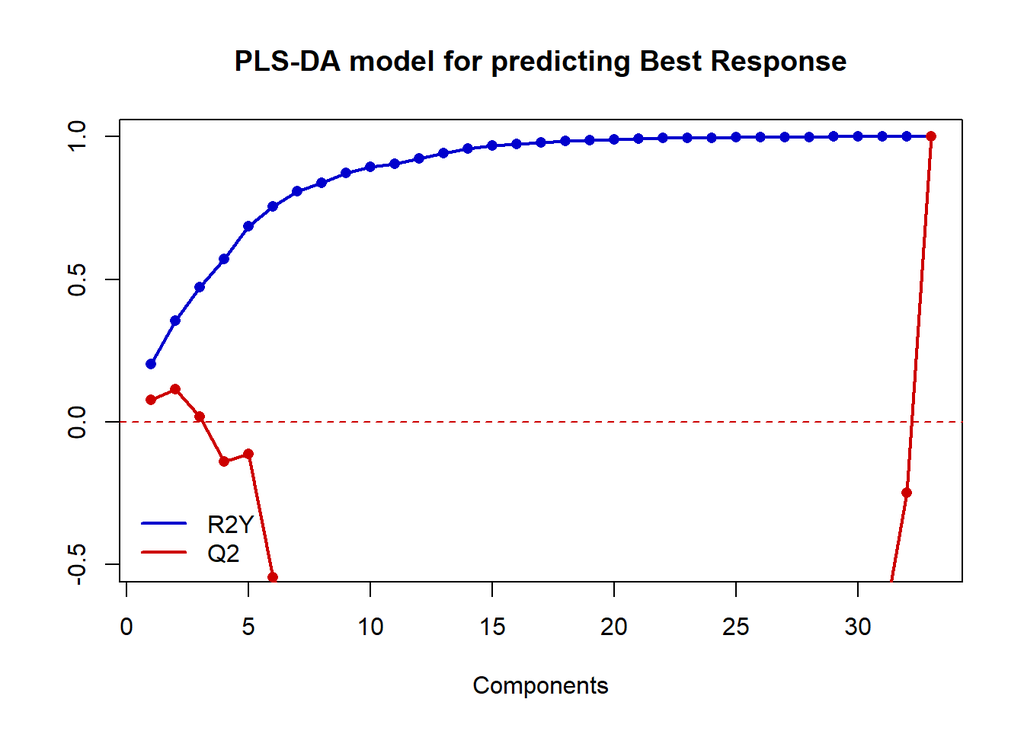

```r
plot(1:33, myplsda2@modelDF$`R2Y(cum)`, type = "o", pch = 16, col = "blue3", lwd = 2, xlab = "Components", ylab = "", main = "PLS-DA model for predicting Best Response", , ylim = c(-0.5, 1))

lines(1:33, myplsda2@modelDF$`Q2(cum)`, type = "o", pch = 16, col = "red3", lwd = 2)
abline(h = 0, col = "red3", lty = 2)
legend("bottomleft", c("R2Y", "Q2"), lwd = 2,
       col = c("blue3", "red3"), bty = "n")
```

```r
myplsda2 = opls(x = X2, y = Y2, predI = 2, crossvalI = nrow(X), scaleC = "standard", fig.pdfC = "none")
```

```
## PLS-DA
## 34 samples x 66 variables and 1 response
## standard scaling of predictors and response(s)
##       R2X(cum) R2Y(cum) Q2(cum) RMSEE pre ort pR2Y  pQ2
## Total    0.327    0.354   0.115 0.347   2   0 0.05 0.05
```

# EXTREME INDIVIDUALS STUDY

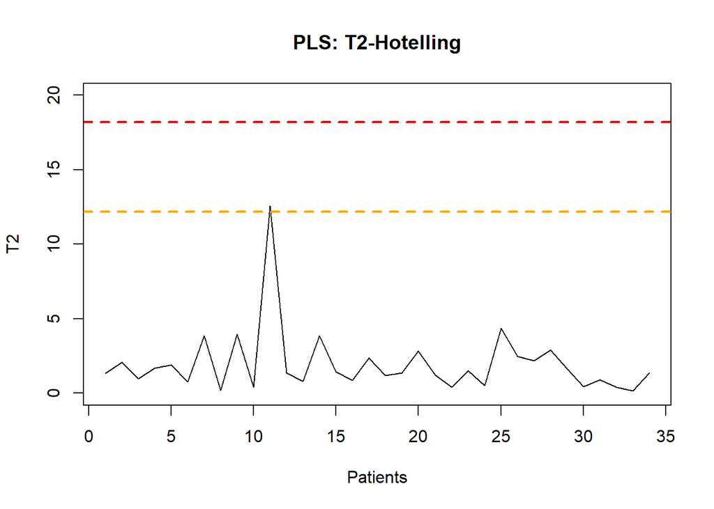

```r
misScores = myplsda2@scoreMN
varT = apply(misScores, 2, var)
miT2 = colSums(t(misScores**2) / varT)
N = nrow(X2)
A = 4
F95 = A*(N**2 - 1)/(N*(N - A)) * qf(0.95, A, N-A);
F99 = A*(N**2 - 1)/(N*(N - A)) * qf(0.99, A, N-A);

plot(1:length(miT2), miT2, type = "l", xlab = "Patients", ylab = "T2",
     main = "PLS: T2-Hotelling",ylim=c(0,20))
abline(h = F95, col = "orange", lty = 2, lwd = 2)
abline(h = F99, col = "red3", lty = 2, lwd = 2)
```

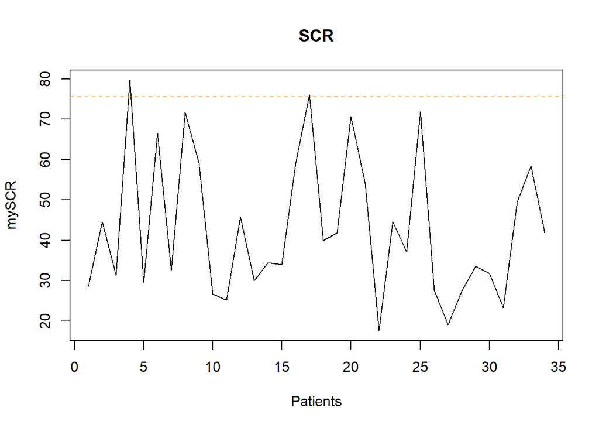

```r
myT = myplsda2@scoreMN
myP = myplsda2@loadingMN
myE = scale(X2) - myT%*%t(myP)
mySCR = rowSums(myE^2)   # SPE
plot(1:length(mySCR), mySCR, type = "l", main = "SCR",
     xlab = "Patients")

g = var(mySCR)/(2*mean(mySCR))
h = (2*mean(mySCR)^2)/var(mySCR)
chi2lim = g*qchisq(0.95, df = h)
abline(h = chi2lim, col = "orange", lty = 2)
chi2lim99 = g*qchisq(0.99, df = h)
abline(h = chi2lim99, col = "red3", lty = 2)
```